# Time Series Decomposition Forecasting of Uber

In this notebook, I will decompose the uber data into trend, seasonal, and remainder components using STL method. Afterwards, I will forecast the seasonaly adjusted series (seasadj) using several approaches. At the end, I will simply add the seasonal component to the seasadj model to make the complete model. I evaluate its performance in great details.

```r
source('uber_data_preprocessing.R')
```

[output not shown]

```r
source('error_metrics.R')
```

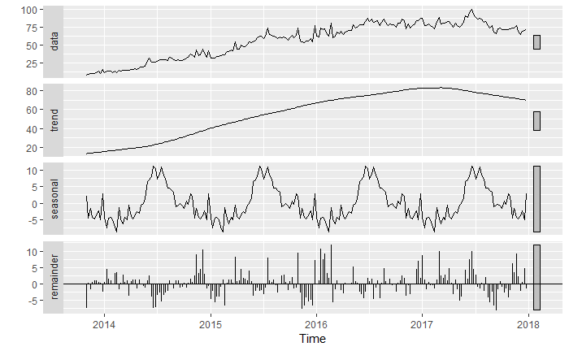

```r
# decomposing the series
uber_decomposed <- stl(uber_train, s.window = 53, t.window = 53)
# looking at different components
autoplot(uber_decomposed)
```

As seen in the plot, the the magnitude of the seasonal component stays almost the same over time (additive). Moreover, as explained earlier, there is a peak in the data in summer months, which could be seen in the seasonal component. Now, I am going to build the seasonally adjusted data (trend + remainder) and try to build an appropriate model for that.

```
Removed 1 rows containing non-finite values (stat_smooth).Removed 1 rows containing missing values (geom_point).Don't know how to automatically pick scale for object of type ts. Defaulting to continuous.
```

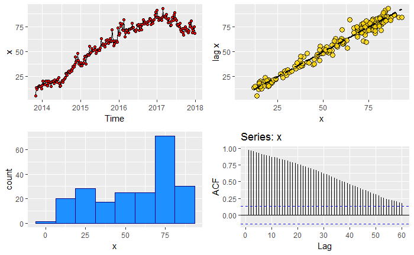

```r
uber_seasadj <- seasadj(uber_decomposed)
four_plot(uber_seasadj)
```

As seen, the data shows a considerable auto-correlation. Also, no obvious outliers could be detected. Based on the previous analyses that I carried out, I believe following models would be good candidates. I will buld them and use cross validation to determine which one is the best.

1 - naive model

2 - random walk with drift

3 - piecewise linear

4 - simple exponential smoothing

5 - ARIMA

```r
# naive model
naive_model <- naive(uber_seasadj)
# random walk with drift
rwdrift_model <- rwf(uber_seasadj, drift = T)
# piecewise linear with break at 2017
t <- time(uber_seasadj)
knot <- 2017.00
tb <- ts(pmax(0, t-knot), start = c(2013,43))
pw_linear_model <- tslm(uber_seasadj ~ t + tb)
# simple exponential smoothing
ses_model <- ses(uber_seasadj)
summary(ses_model)
```

```
Forecast method: Simple exponential smoothing

Model Information:
Simple exponential smoothing

Call:
 ses(y = uber_seasadj)

  Smoothing parameters:
    alpha = 0.5379

  Initial states:
    l = 9.3063

  sigma:  3.7149

     AIC     AICc      BIC
1740.993 1741.106 1751.133

Error measures:
                    ME     RMSE      MAE      MPE     MAPE      MASE         ACF1
Training set 0.5264104 3.697776 2.796631 1.035566 6.368225 0.1368292 -0.002000561

Forecasts:
```

|  | Point Forecast | Lo 80 | Hi 80 | Lo 95 | Hi 95 |
| --- | --- | --- | --- | --- | --- |
| 2018.000 | 70.75196 | 65.99108 | 75.51284 | 63.47082 | 78.03310 |
| 2018.019 | 70.75196 | 65.34601 | 76.15790 | 62.48428 | 79.01964 |
| 2018.038 | 70.75196 | 64.77011 | 76.73381 | 61.60351 | 79.90041 |
| 2018.058 | 70.75196 | 64.24498 | 77.25894 | 60.80039 | 80.70352 |
| 2018.077 | 70.75196 | 63.75917 | 77.74474 | 60.05742 | 81.44650 |
| 2018.096 | 70.75196 | 63.30499 | 78.19892 | 59.36281 | 82.14111 |
| 2018.115 | 70.75196 | 62.87696 | 78.62695 | 58.70819 | 82.79572 |
| 2018.135 | 70.75196 | 62.47103 | 79.03289 | 58.08737 | 83.41655 |
| 2018.154 | 70.75196 | 62.08408 | 79.41983 | 57.49559 | 84.00833 |
| 2018.173 | 70.75196 | 61.71369 | 79.79023 | 56.92912 | 84.57480 |

```r
# arima model
arima_model <- auto.arima(uber_seasadj, approximation = F, stepwise = F, seasonal = F)
summary(arima_model)
```

```
Series: uber_seasadj
ARIMA(0,1,5) with drift

Coefficients:
          ma1      ma2     ma3      ma4      ma5   drift
      -0.4504  -0.1035  0.2725  -0.1735  -0.1365  0.2924
s.e.   0.0673   0.0761  0.0746   0.0741   0.0674  0.0997

sigma^2 estimated as 12.86:  log likelihood=-579.62
AIC=1173.23   AICc=1173.77   BIC=1196.86

Training set error measures:
                     ME     RMSE      MAE       MPE     MAPE      MASE         ACF1
Training set 0.02843689 3.527889 2.726301 0.1741837 6.023312 0.1333882 0.0002909486
```

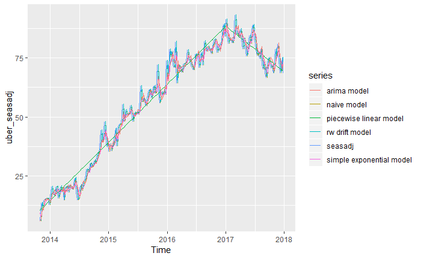

```r
autoplot(uber_seasadj, series='seasadj') +
autolayer(fitted(naive_model), series='naive model') +
autolayer(fitted(rwdrift_model), series='rw drift model')+
autolayer(fitted(pw_linear_model), series='piecewise linear model')+
autolayer(fitted(ses_model), series='simple exponential model')+
autolayer(fitted(arima_model), series='arima model')
```

Visually, it seems that all models provide a good fit. Now, lets take a look at the error metrics on the training data.

```r
print('naive model performance')
```

```
[1] "naive model performance"
```

```r
accuracy(naive_model)
```

```
                   ME     RMSE      MAE       MPE     MAPE      MASE       ACF1
Training set 0.290525 4.041808 3.057228 0.6294546 6.600216 0.1495793 -0.3238258
```

```r
print('random walk with drift model performance')
```

```
[1] "random walk with drift model performance"
```

```r
accuracy(rwdrift_model)
```

```
                       ME     RMSE      MAE        MPE     MAPE      MASE       ACF1
Training set 1.737091e-13 4.031353 3.038314 -0.0717464 6.559402 0.1486539 -0.3238258
```

```r
print('piecewise linear model performance')
```

```
[1] "piecewise linear model performance"
```

```r
accuracy(pw_linear_model)
```

```
                        ME     RMSE      MAE       MPE     MAPE      MASE
Training set -8.129868e-17 4.376259 3.378307 -1.772857 8.309279 0.1615252
```

```r
print('simple exponential model performance')
```

```
[1] "simple exponential model performance"
```

```r
accuracy(ses_model)
```

```
                    ME     RMSE      MAE      MPE     MAPE      MASE         ACF1
Training set 0.5264104 3.697776 2.796631 1.035566 6.368225 0.1368292 -0.002000561
```

```r
print('arima model performance')
```

```
[1] "arima model performance"
```

```r
accuracy(arima_model)
```

```
                     ME     RMSE      MAE       MPE     MAPE      MASE         ACF1
Training set 0.02843689 3.527889 2.726301 0.1741837 6.023312 0.1333882 0.0002909486
```

As seen, the performance of all model except piecewise linear is the same. With regards to the piecewise linear model, I believe the trend after year 2017 is decreasing with a considerable slope; hence, it would be a bit danegrous to forecast the year 2018 with this model. Therefore, I exclude piecewise linear model and I investigate the cross validatio errors for other four models.

```r
naive_error <- tsCV(uber_seasadj, naive, h=1)
rwdrift_error <- tsCV(uber_seasadj, rwf,drift=T, h=1)
ses_error <- tsCV(uber_seasadj, ses, h=1)
farima <- function(x,h){
    fit <- Arima(x, order=c(2,1,0), seasonal=c(0,0,0), include.drift = T)
    return(forecast(fit, h=h))
}
arima_error <- tsCV(uber_seasadj, farima, h=1)
```

```r
rmse(naive_error)
```

```
[1] 4.015571
```

```r
rmse(rwdrift_error)
```

```
[1] 4.094134
```

```r
rmse(ses_error)
```

```
[1] 3.758943
```

```r
rmse(arima_error)
```

```
[1] 3.754971
```

As seen, the simple exponential model and arima model deliver a lower RMSE value on the cross validation. Their value is very close to each other. To decide on the best model, I would like to look at the residual plots to see which model makes me happier.

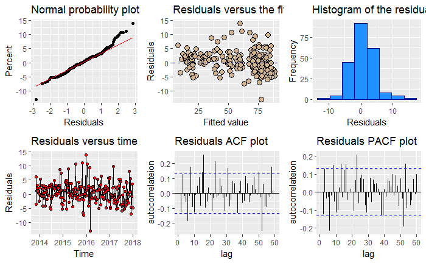

```r
residual_diognostics_plots(ses_model)
```

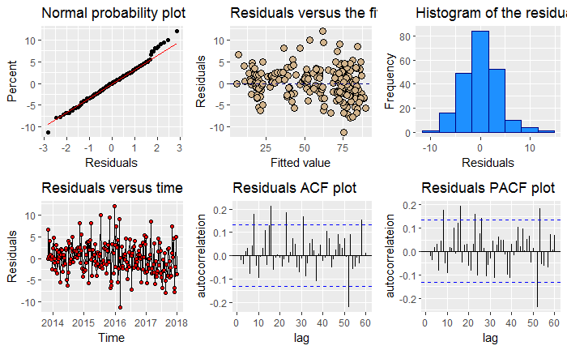

```r
residual_diognostics_plots(arima_model)
```

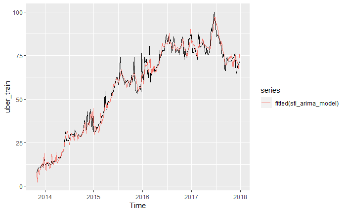

```r
farima <- function(x,h, level){
    fit <- Arima(x, order=c(2,1,0), seasonal=c(0,0,0), include.drift = T)
    return(forecast(fit, h=h, level=level))
}
stl_arima_model <- stlf(uber_train, s.window = 53, forecastfunction=farima, h=length(uber_test))
autoplot(uber_train) +
autolayer(fitted(stl_arima_model))
```

As seen, the model provides a good fit. Lets look at the error metrics on the training data.

```r
accuracy(stl_arima_model)
```

```
                     ME     RMSE      MAE       MPE     MAPE      MASE        ACF1
Training set 0.01568877 3.582961 2.738304 0.4565601 6.214744 0.1339737 0.003906471
```

The error metrics look good. Lets, see how model performs on the cross validation.

```r
fstlarima <- function(x,h){
    fit <- stlf(x, s.window = 53, forecastfunction=farima, h=h)
    return(forecast(fit, h=h))
}
stl_arima_error <- tsCV(uber_train, fstlarima, h=1)
print(rmse(stl_arima_error))
```

```
[1] 5.167753
```

The RMSE value is not bad. Lets look at the residuals.

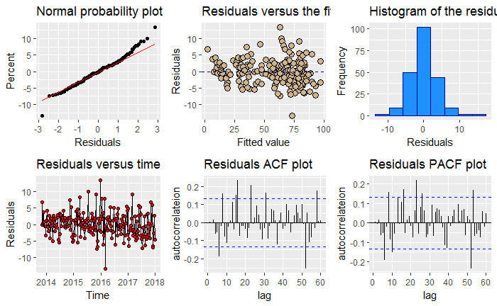

```r
residual_diognostics_plots(stl_arima_model)
```

The residual plots suggest that the residuals follow a normal distribution (with a couple of outliers). There is no obvious pattern in the residuals vs fitted value plot. The variation of the residuals stays almost the same over time. However, there are sime spikes in first twnty lags in ACF and PACF plots (but not in first 5 lags). There is a spike in the lags 52, showing that the seasonality is not explained very good. Actually, I believe this model almost satisfactorilly passes the residuals test. Now, lets make the ofrecast for the year 2018 with this model.

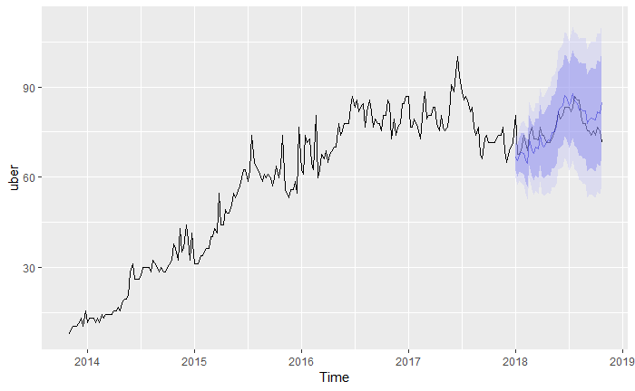

```r
stl_arima_fcst <- forecast(stl_arima_model, h=length(uber_test))
autoplot(uber) +
autolayer(stl_arima_fcst, alpha=0.4)
```

As seen, the model delivers a greta forecast for the year 2018. Lets look at some error metrics.

```r
accuracy(stl_arima_fcst, uber)
```

```
                      ME     RMSE      MAE        MPE     MAPE      MASE        ACF1 Theil's U
Training set  0.01568877 3.582961 2.738304  0.4565601 6.214744 0.1339737 0.003906471        NA
Test set     -0.32212786 4.540072 3.540401 -0.3923820 4.653922 0.1732169 0.551372466  1.306855
```

The RMSE and MAPE values for this model on both training and testing sets are good. This model could be considered a good fit; however, I believe the seasonality in the data is not captured very well yet. Based on my analyses so fat, I believe that the arima model can explain the time dependency and trend of the data very well. The fourier terms (harmonic of order 3) could explain the seasonality nicely. So, lets combine thsese two and build a harmonic dynamic model to see how it performs. In the next notebook, I will develope a dynamic model with harmonics. Stay tuned.